# Video_Game

Hernan Gio Cortez

4/10/2023

## Introduction

For this case study, I used the video game sales dataset from Kaggle to apply data exploration, cleaning, analysis and visualization. During the process, I used R programming language to code and demostrate my thought process working with this dataset.

## Stage 1: Ask questions and identify tasks

Business Tasks:

- Exploration and analysis
- Show the sales trend from 1980 to 2017
- Identify the top performing region, genre, platform and publishers

## Stage 2: Preparation

- Data: [here](https://www.kaggle.com/datasets/gregorut/videogamesales)
- License: [here](https://github.com/GregorUT/vgchartzScrape/blob/master/LICENSE)
- Description: This dataset contains a list of video games with sales greater than 100,000 copies.

Fields include

- Rank - Ranking of overall sales
- Name - The games name
- Platform - Platform of the games release (i.e. PC,PS4, etc.)
- Year - Year of the game’s release
- Genre - Genre of the game
- Publisher - Publisher of the game
- NA_Sales - Sales in North America (in millions)
- EU_Sales - Sales in Europe (in millions)
- JP_Sales - Sales in Japan (in millions)
- Other_Sales - Sales in the rest of the world (in millions)
- Global_Sales - Total worldwide sales.

## Stage 3: Process the Data

### Loading the libraries and importing data

This process is important in R programming language to be able to use the functions in these libraries.

```r
#install.packages("tidyverse")
#install.packages("ggplot2")
#install.packages("dplyr")
#install.packages("data.table")
library("tidyverse")
library("ggplot2")
library("dplyr")
library("data.table")
```

```r
setwd("/Users/hernangio/Documents/Data Analyst/Portfolio/01 Data")
video_games <- read.csv("vgsales.csv")
```

### Observing the data

Check the class of the columns and visualize the top rows of the data using `head()` and `str()`.

```r
head(video_games)
```

```
##   Rank                     Name Platform Year        Genre Publisher NA_Sales
## 1    1               Wii Sports      Wii 2006       Sports  Nintendo    41.49
## 2    2        Super Mario Bros.      NES 1985     Platform  Nintendo    29.08
## 3    3           Mario Kart Wii      Wii 2008       Racing  Nintendo    15.85
## 4    4        Wii Sports Resort      Wii 2009       Sports  Nintendo    15.75
## 5    5 Pokemon Red/Pokemon Blue       GB 1996 Role-Playing  Nintendo    11.27
## 6    6                   Tetris       GB 1989       Puzzle  Nintendo    23.20
##   EU_Sales JP_Sales Other_Sales Global_Sales
## 1    29.02     3.77        8.46        82.74
## 2     3.58     6.81        0.77        40.24
## 3    12.88     3.79        3.31        35.82
## 4    11.01     3.28        2.96        33.00
## 5     8.89    10.22        1.00        31.37
## 6     2.26     4.22        0.58        30.26
```

```r
str(video_games)
```

```
## 'data.frame':    16598 obs. of  11 variables:
##  $ Rank        : int  1 2 3 4 5 6 7 8 9 10 ...
##  $ Name        : chr  "Wii Sports" "Super Mario Bros." "Mario Kart Wii" "Wii Sports Resort" ...
##  $ Platform    : chr  "Wii" "NES" "Wii" "Wii" ...
##  $ Year        : chr  "2006" "1985" "2008" "2009" ...
##  $ Genre       : chr  "Sports" "Platform" "Racing" "Sports" ...
##  $ Publisher   : chr  "Nintendo" "Nintendo" "Nintendo" "Nintendo" ...
##  $ NA_Sales    : num  41.5 29.1 15.8 15.8 11.3 ...
##  $ EU_Sales    : num  29.02 3.58 12.88 11.01 8.89 ...
##  $ JP_Sales    : num  3.77 6.81 3.79 3.28 10.22 ...
##  $ Other_Sales : num  8.46 0.77 3.31 2.96 1 0.58 2.9 2.85 2.26 0.47 ...
##  $ Global_Sales: num  82.7 40.2 35.8 33 31.4 ...
```

### Cleaning

Upon checking, I found out that the class of Year column is **character**. I changed the class of Year column using `as.numeric`.

```r
video_games$Year <- as.numeric(video_games$Year)
table(video_games[,4] == "N/A", useNA = "a")
```

```
##
## FALSE  <NA>
## 16327   271
```

```r
table(video_games[,6] == "N/A", useNA = "a")
```

```
##
## FALSE  TRUE  <NA>
## 16540    58     0
```

Upon checking, I found out that there are **271 rows** without Year values and **58 rows** without Publisher. I excluded the rows without Year values and converted Publisher with NA values to “Unknown”

```r
video_games <- subset(video_games, is.na(Year) == FALSE)
video_games$Publisher <- ifelse(video_games$Publisher == "N/A", NA, video_games$Publisher)
video_games$Publisher <- ifelse(is.na(video_games$Publisher), "Unknown" , video_games$Publisher)
```

Check for NA values

```r
table(video_games$Year == "N/A", useNA = "a")
```

```
##
## FALSE  <NA>
## 16327     0
```

```r
table(video_games$Publisher == "N/A", useNA = "a")
```

```
##
## FALSE  <NA>
## 16327     0
```

Check if there are any duplicated rows

```r
nrow(video_games[duplicated(video_games),])
```

```
## [1] 0
```

Check Year column

```r
sort(unique(video_games$Year))
```

```
##  [1] 1980 1981 1982 1983 1984 1985 1986 1987 1988 1989 1990 1991 1992 1993 1994
## [16] 1995 1996 1997 1998 1999 2000 2001 2002 2003 2004 2005 2006 2007 2008 2009
## [31] 2010 2011 2012 2013 2014 2015 2016 2017 2020
```

```r
sum(ifelse(video_games$Year == 2020, 1,0))
```

```
## [1] 1
```

I excluded **1 row** under year 2020 for the final dataset

```r
video_games <- subset(video_games, Year != 2020)
```

## Stage 4: Analysis and Visualization

### Summary of the top performing video games (top 100)

```r
top_video_games <- video_games[1:100,]
summary(top_video_games)
```

```
##       Rank            Name             Platform              Year
##  Min.   :  1.00   Length:100         Length:100         Min.   :1982
##  1st Qu.: 25.75   Class :character   Class :character   1st Qu.:2001
##  Median : 50.50   Mode  :character   Mode  :character   Median :2007
##  Mean   : 50.50                                         Mean   :2005
##  3rd Qu.: 75.25                                         3rd Qu.:2011
##  Max.   :100.00                                         Max.   :2015
##     Genre            Publisher            NA_Sales         EU_Sales
##  Length:100         Length:100         Min.   : 0.980   Min.   : 0.010
##  Class :character   Class :character   1st Qu.: 3.862   1st Qu.: 2.315
##  Mode  :character   Mode  :character   Median : 5.675   Median : 3.385
##                                        Mean   : 7.050   Mean   : 4.207
##                                        3rd Qu.: 8.290   3rd Qu.: 5.043
##                                        Max.   :41.490   Max.   :29.020
##     JP_Sales       Other_Sales      Global_Sales
##  Min.   : 0.000   Min.   : 0.080   Min.   : 7.340
##  1st Qu.: 0.235   1st Qu.: 0.550   1st Qu.: 8.975
##  Median : 1.635   Median : 0.865   Median :11.255
##  Mean   : 2.046   Mean   : 1.318   Mean   :14.620
##  3rd Qu.: 3.280   3rd Qu.: 1.620   3rd Qu.:15.925
##  Max.   :10.220   Max.   :10.570   Max.   :82.740
```

### Global Sales per Year

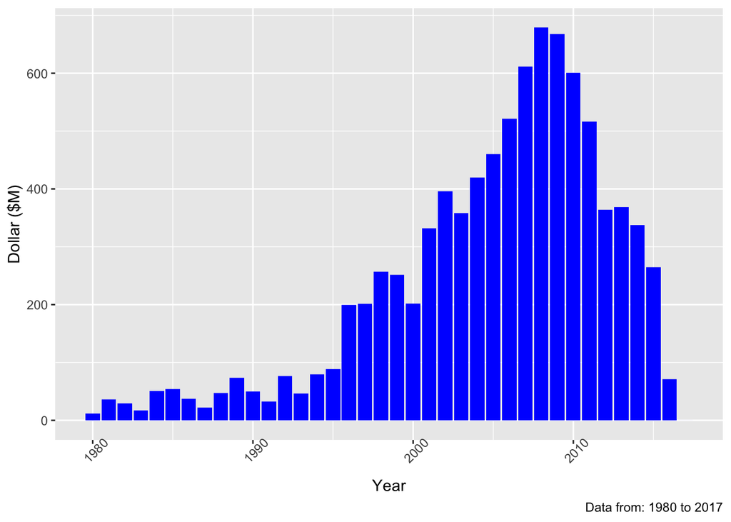

### Genre

```r
salesxgenre <- video_games %>%
  select(Genre,NA_Sales, EU_Sales, JP_Sales, Other_Sales, Global_Sales) %>%
  group_by(Genre) %>% summarize(
    NA_Sales_Total = sum(NA_Sales),
    JP_Sales_Total = sum(JP_Sales),
    Other_Sales_Total = sum(Other_Sales),
    Global_Sales_Total = sum(Global_Sales)
  ) %>%
  arrange(desc(Global_Sales_Total))
colnames(salesxgenre) <- c("Genre", "NA_Sales", "EU_Sales", "JP_Sales", "Other_Sales", "Global_Sales")
setDT(salesxgenre)
salesxgenre
```

```
##            Genre NA_Sales EU_Sales JP_Sales Other_Sales
##  1:       Action   861.80   158.66   184.92     1722.88
##  2:       Sports   670.09   134.76   132.65     1309.24
##  3:      Shooter   575.16    38.18   101.90     1026.20
##  4: Role-Playing   326.50   350.29    59.38      923.84
##  5:     Platform   445.99   130.65    51.51      829.15
##  6:         Misc   402.48   106.67    74.02      797.62
##  7:       Racing   356.93    56.61    76.68      726.77
##  8:     Fighting   220.74    87.15    36.19      444.05
##  9:   Simulation   181.51    63.54    31.34      389.87
## 10:       Puzzle   122.01    56.68    12.47      242.22
## 11:    Adventure   102.06    52.01    16.70      234.80
## 12:     Strategy    67.89    49.10    11.23      173.43
```

### Platform

```r
salesxplatform <- video_games %>%
  select(Platform,NA_Sales, EU_Sales, JP_Sales, Other_Sales, Global_Sales) %>%
  group_by(Platform) %>% summarize(
    NA_Sales_Total = sum(NA_Sales),
    JP_Sales_Total = sum(JP_Sales),
    Other_Sales_Total = sum(Other_Sales),
    Global_Sales_Total = sum(Global_Sales)
  ) %>%
  arrange(desc(Global_Sales_Total))

colnames(salesxplatform) <- c("Platform", "NA_Sales", "EU_Sales", "JP_Sales", "Other_Sales", "Global_Sales")
setDT(salesxplatform)
salesxplatform
```

```
##     Platform NA_Sales EU_Sales JP_Sales Other_Sales
##  1:      PS2   572.92   137.54   190.47     1233.46
##  2:     X360   594.33    12.30    84.67      969.61
##  3:      PS3   388.90    79.21   140.81      949.35
##  4:      Wii   497.37    68.28    79.20      909.81
##  5:       DS   388.29   175.02    60.27      818.67
##  6:       PS   334.71   139.78    40.69      727.39
##  7:      GBA   184.12    46.56     7.61      313.56
##  8:      PSP   107.09    75.89    41.52      291.71
##  9:      PS4    96.80    14.30    43.36      278.10
## 10:       PC    92.10     0.17    24.33      255.05
## 11:       GB   113.64    85.12     8.16      254.42
## 12:       XB   182.06     1.38     8.48      252.09
## 13:      NES   125.94    98.65     5.31      251.07
## 14:      3DS    78.03    97.30    12.55      246.28
```

[output cut: 18 more lines]

### Publisher

```r
salesxpublisher <- video_games %>%
  select(Publisher,NA_Sales, EU_Sales, JP_Sales, Other_Sales, Global_Sales) %>%
  group_by(Publisher) %>% summarize(
    NA_Sales_Total = sum(NA_Sales),
    JP_Sales_Total = sum(JP_Sales),
    Other_Sales_Total = sum(Other_Sales),
    Global_Sales_Total = sum(Global_Sales)
  ) %>%
  arrange(desc(Global_Sales_Total))

colnames(salesxpublisher) <- c("Publisher", "NA_Sales", "EU_Sales", "JP_Sales", "Other_Sales", "Global_Sales")
setDT(salesxpublisher)
salesxpublisher
```

```
##                        Publisher NA_Sales EU_Sales JP_Sales Other_Sales
##   1:                    Nintendo   815.75   454.99    95.19     1784.43
##   2:             Electronic Arts   584.22    13.98   127.63     1093.39
##   3:                  Activision   426.01     6.54    74.79      721.41
##   4: Sony Computer Entertainment   265.22    74.10    80.40      607.28
##   5:                     Ubisoft   252.54     7.33    50.14      473.25
##  ---
## 572:                      Piacci     0.00     0.01     0.00        0.01
## 573:                  Rain Games     0.00     0.00     0.00        0.01
## 574:             Stainless Games     0.01     0.00     0.00        0.01
## 575:                      Takuyo     0.00     0.01     0.00        0.01
## 576:           UIG Entertainment     0.00     0.00     0.00        0.01
```

### Global Sales by Genre and Publisher

```r
genrexpublisher <- video_games %>%
  select(Genre, Publisher, Global_Sales)

genrexpublisher <- subset(genrexpublisher, Publisher %in% c("Nintendo", "Electronic Arts", "Activision", "Sony Computer Entertainment"))
```

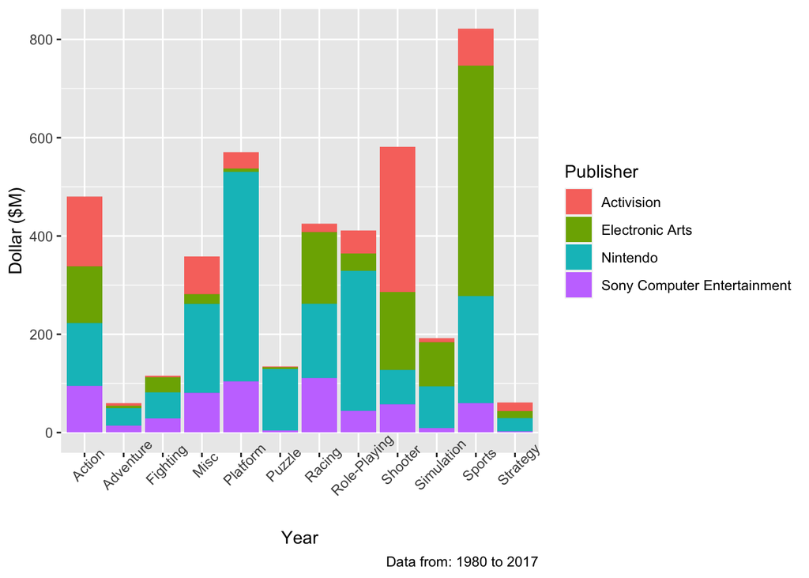

The top 4 publishers were considered in this chart to visualize the video game sales distribution by genre in these publishers.